# PISA 2012 data exploration

### by Omar Omran

> The PISA database contains the full set of responses from individual students regarding their education.

## Univariate Exploration

### Distrubution of Learning time

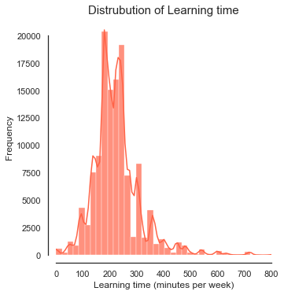

We can see that there many spikes in the distrubution but it fairly follows a normal distrubution pattern

### In what month to have your baby if you want his chances of being smart high ?

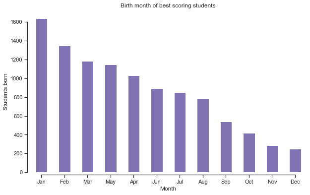

From the bar chart shown, we can conclude the a big portion of the number of kids who score grades higher than 2 are born in January

### Does being interested in a subject, make you enjoy it ?

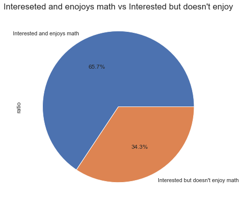

Generally speaking, Being interested in something doesn't necessarily mean you will enjoy it

## Bivariate Exploration

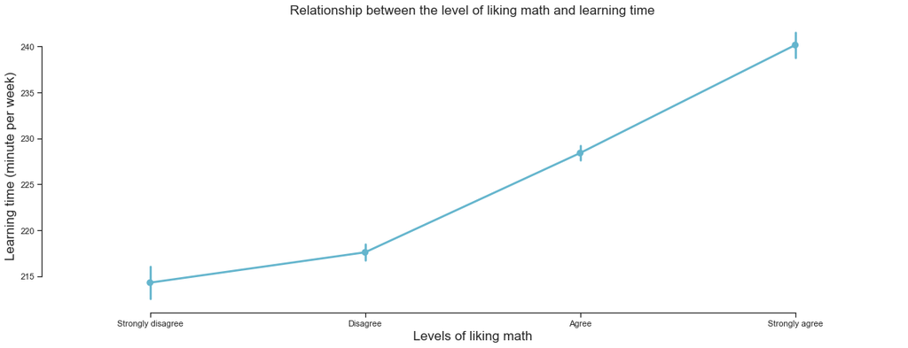

It is obvious that the more the students like math, the more they will spend more time learning

### The relationship between gender and learning time

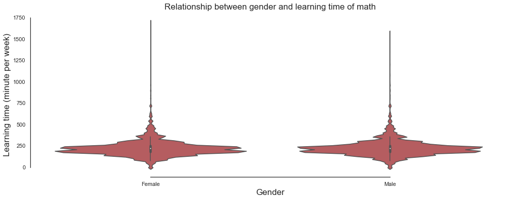

### Does the level of education of the parents affects the learning time of their children ?

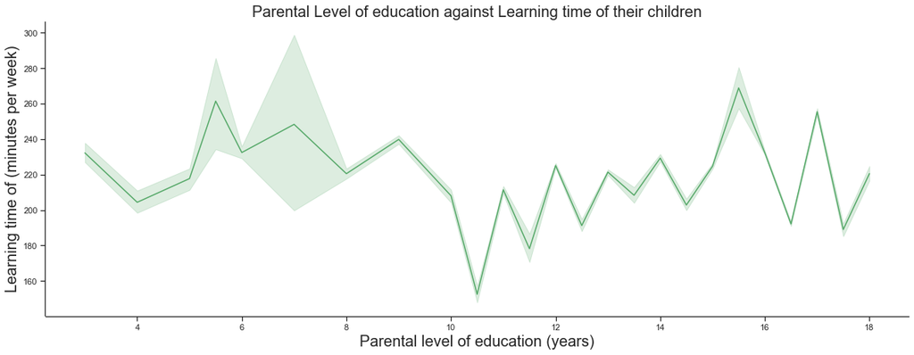

There is an unexpected pattern that appears to exit here; Many fluctuations occur and surprisingly at about 10-12 years of parental education,children tend to spend less time learning than those whom parents have lower level of education, We can confirm this by looking at the bar chart below

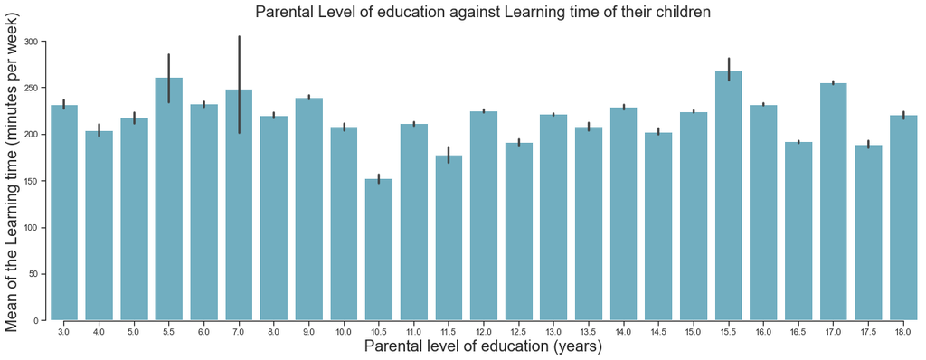

Taking a look at the bar chart, we can see that the unexpected drop exists when the parental level of education is at 10.5.

### The correlatoin between the wealth of the parents and the learning time of their children

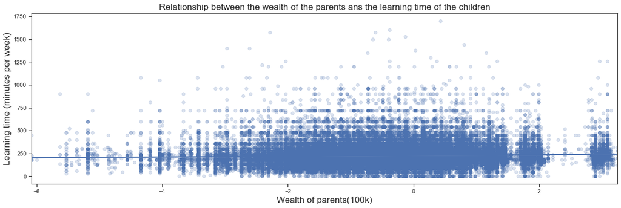

From the scatter plot shown, There doesn't seem to be a relation between the wealth of the family and the learning time of the children

### The Relationship between Learning time vs Wealth and Sex

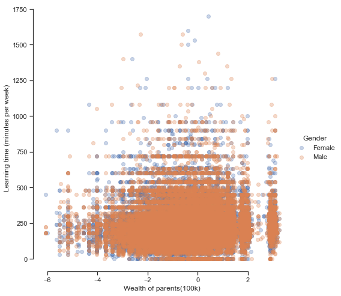

From the scatter plot shown, we can see that it is difficult to interpret anything from the visual. A facet grid is required to figure out the pattern.

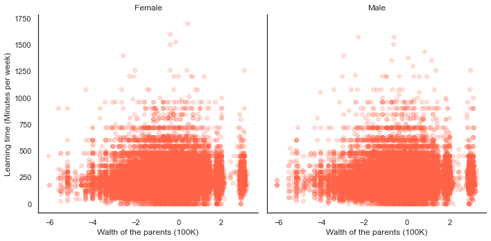

From the results, We can interpret that the sex doesn't have a major effect combined with wealth on the learning time as almost the two charts are identical